# CSCI E-63C Week 13 Problem Set

# 1 Preface

The goal of this problem set is to develop some intuition about the impact of the number of nodes in the hidden layer of the neural network. We will use few simulated examples to have clear understanding of the structure of the data we are modeling and will assess how performance of the neural network model is impacted by the structure in the data and the setup of the network.

First of all, to compensate for lack of coverage on this topic in ISLR, let’s go over a couple of simple examples. We start with simulating a simple two class dataset in 2D predictor space with an outcome representative of an interaction between attributes. (Please notice that for the problems you will be working on this week you will be asked below to simulate a dataset using a different model.)

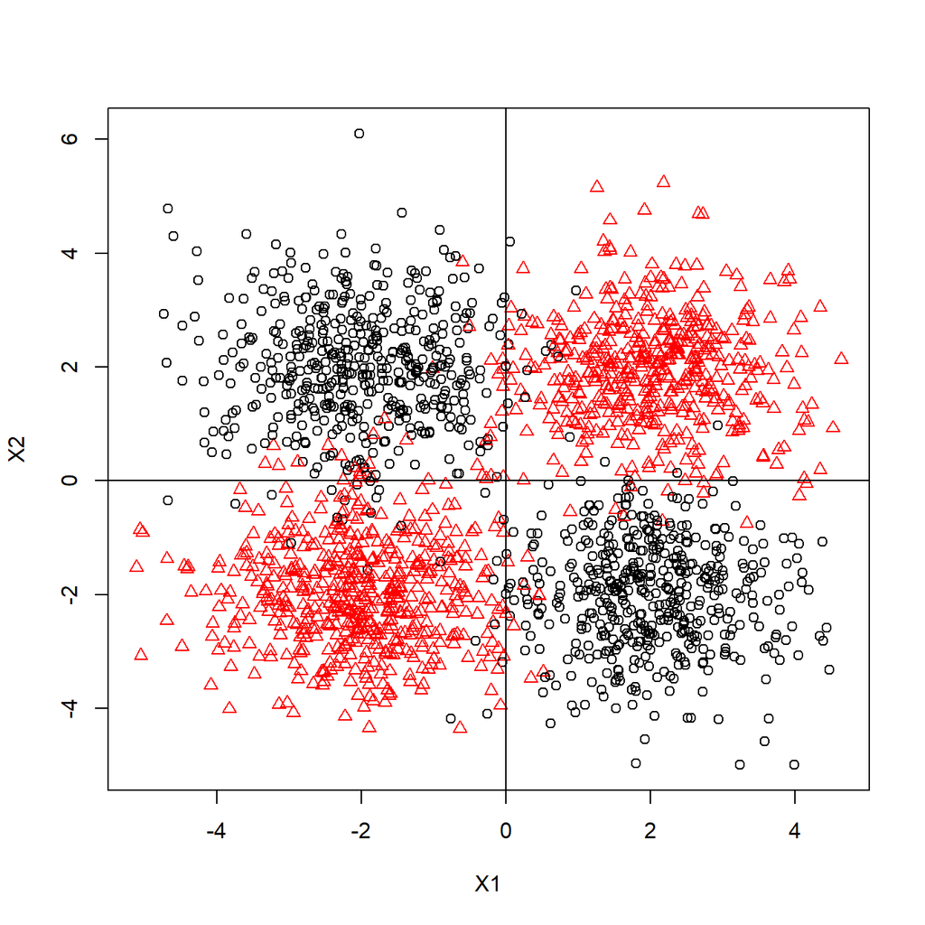

```r
# fix seed so that narrative always matches the plots:
set.seed(1234567890)
nObs <- 1000
ctrPos <- 2
xyTmp <- matrix(rnorm(4*nObs),ncol=2)
xyCtrsTmp <- matrix(sample(c(-1,1)*ctrPos,nObs*4,replace=TRUE),ncol=2)
xyTmp <- xyTmp + xyCtrsTmp
gTmp <- paste0("class",(1+sign(apply(xyCtrsTmp,1,prod)))/2)
plot(xyTmp,col=as.numeric(factor(gTmp)),pch=as.numeric(factor(gTmp)),xlab="X1",ylab="X2")
abline(h=0)
abline(v=0)
```

Symbol color and shape indicate class. Typical problem that will present a problem for any approach estimating a single linear decision boundary. We used similar simulated data for the random forest (week 10) problem set.

## 1.1 One hidden node

We can fit simple neural network (using all default values in the call to `neuralnet` – notice that both covariates and outcome have to be numeric as opposed to factor) and plot its layout (allowing for its output to be included in Rmarkdown generated report actually seems to be quite painful - one has to overwrite original implementation of `plot.nn` with the one that doesn’t call `dev.new()` that is included in this Rmarkdown file with `echo=FALSE` – to do the same you have to include that block into your Rmarkdown file also):

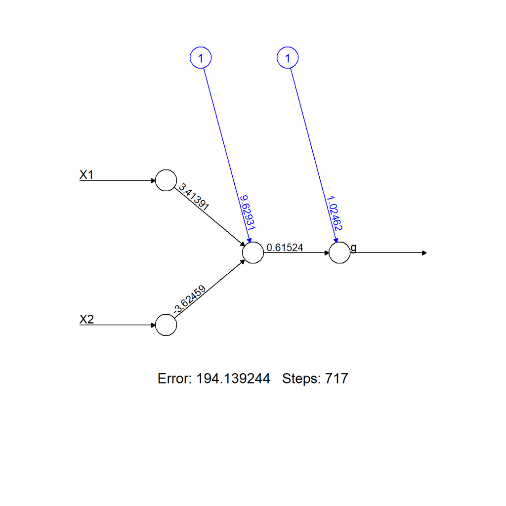

```r
### Doesn't run: "requires numeric/complex ... arguments"
### nnRes <- neuralnet(g~X1+X2,data.frame(g=gTmp,xyTmp))
nnRes <- neuralnet(g~X1+X2,data.frame(g=as.numeric(factor(gTmp)),xyTmp))
plot(nnRes)
```

That shows us a model with one node in a single hidden layer (default parameters).

We can lookup actual model predictions and recalculate them from input variables (in the field `covariate`) and model weight and activation function (fields `weights` and `act.fct` respectively):

```r
head(nnRes$net.result[[1]])
```

```
##          [,1]
## [1,] 1.639856
## [2,] 1.042447
## [3,] 1.639856
## [4,] 1.024622
## [5,] 1.639856
## [6,] 1.503985
```

```r
cbind(rep(1,6),nnRes$act.fct(cbind(rep(1,6),nnRes$covariate[1:6,])%*%nnRes$weights[[1]][[1]]))%*%nnRes$weights[[1]][[2]]
```

```
##          [,1]
## [1,] 1.639856
## [2,] 1.042447
## [3,] 1.639856
## [4,] 1.024622
## [5,] 1.639856
## [6,] 1.503985
```

Notice that input parameter `linear.output` governs whether activation function is called on the value of the output node or not:

```r
nnResNLO <- neuralnet(g~X1+X2,data.frame(g=as.numeric(factor(gTmp)),xyTmp),linear.output=FALSE)
head(nnResNLO$net.result[[1]])
```

```
##           [,1]
## [1,] 0.9999903
## [2,] 0.9999904
## [3,] 0.9999903
## [4,] 0.9999905
## [5,] 0.9999903
## [6,] 0.9999904
```

```r
nnResNLO$act.fct(cbind(rep(1,6),nnResNLO$act.fct(cbind(rep(1,6),nnResNLO$covariate[1:6,])%*%nnResNLO$weights[[1]][[1]]))%*%nnResNLO$weights[[1]][[2]])
```

```
##           [,1]
## [1,] 0.9999903
## [2,] 0.9999904
## [3,] 0.9999903
## [4,] 0.9999905
## [5,] 0.9999903
## [6,] 0.9999904
```

```r
quantile(nnResNLO$net.result[[1]])
```

```
##        0%       25%       50%       75%      100%
## 0.9999902 0.9999903 0.9999904 0.9999904 0.9999905
```

As the last statement (the quantiles of the predicted out) above shows, the use of activation function limiting predicted values to $[0;1]$ range when modeling outcome taking values outside of $[0;1]$ interval does not result in a very useful model. In this case with true outcome values constrained to $\{1,2\}$ so that the error is minimized by predicting every outcome to be as close to $1$ as possible.

Using binary – 0 or 1 – outcome produces more useful model when activation function is applied to the output node (`linear.output=FALSE`) and allows use of cross-entropy error function (often used in classification setting in combination with the activation function applied to the output layer):

```r
nnResNLO01 <- neuralnet(g~X1+X2,data.frame(g=as.numeric(factor(gTmp))-1,xyTmp),linear.output=FALSE)
quantile(nnResNLO01$net.result[[1]],c(0,0.1,0.25,0.5,1))
```

```
##         0%        10%        25%        50%       100%
## 0.03744930 0.03908482 0.56598177 0.63918306 0.63925921
```

```r
if ( FALSE ) {
  # from v.3.5.x(?) this started to throw an error instead of silent switch to "sse":
  nnResNLO12CE <- neuralnet(g~X1+X2,data.frame(g=as.numeric(factor(gTmp)),xyTmp),linear.output=FALSE,err.fct="ce")
}
nnResNLO01CE <- neuralnet(g~X1+X2,data.frame(g=as.numeric(factor(gTmp))-1,xyTmp),linear.output=FALSE,err.fct="ce")
head(nnResNLO01CE$net.result[[1]])
```

```
##            [,1]
## [1,] 0.63765805
## [2,] 0.04001203
## [3,] 0.63765803
## [4,] 0.01075720
## [5,] 0.63765804
## [6,] 0.52643332
```

```r
nnResNLO01CE$act.fct(cbind(rep(1,6),nnResNLO01CE$act.fct(cbind(rep(1,6),nnResNLO01CE$covariate[1:6,])%*%nnResNLO01CE$weights[[1]][[1]]))%*%nnResNLO01CE$weights[[1]][[2]])
```

```
##            [,1]
## [1,] 0.63765805
## [2,] 0.04001203
## [3,] 0.63765803
## [4,] 0.01075720
## [5,] 0.63765804
## [6,] 0.52643332
```

```r
quantile(nnResNLO01CE$net.result[[1]])
```

```
##         0%        25%        50%        75%       100%
## 0.01073063 0.57038679 0.63728499 0.63765658 0.63765805
```

We can plot model output indicating class identity (left panel below) that tells us that when true outcome values are constrained to 1 or 2, sum of squared errors is used as error function and output node values are used as-is (not transformed by activation function – `linear.output=TRUE` by default), the majority of the points were estimated to be close to 1 or 1.6 and that majority of those estimated to be close to 1 correspond to the about half of the observations at the first level of the class factor (i.e. numerical value of 1). It is also easy to see that those with predicted value of 1.6 represent roughly 1:2 mix of observations from the first and second levels of the outcome respectively, so that $1.6 \approx (1+2*2)/3 = 5/3$ approximately equals average of their numerical values corresponding to the levels of the factor representing them.

The nature of the model estimated by `neuralnet` in this (very simple!) case becomes even more intuitive if we render all points in the area encompassing our training set with model predictions and overlay training dataset on top of that (right panel below). It is immediately apparent that this model identified a line in this 2D space separating one cloud of points belonging mostly to one class from all others so that predicted values are approximately equal to the average outcome on each side of this decision boundary.

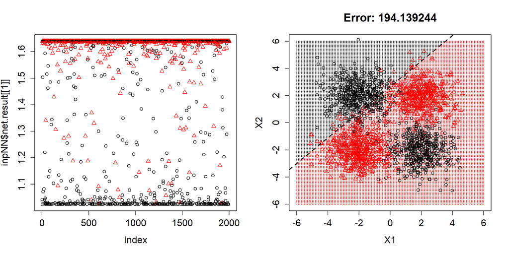

```r
plotNNpreds2D2class <- function(inpNN,inpClassThresh,inpGrid=(-60:60)/10) {
  tmpClrPch <- as.numeric(factor(inpNN$response))
  plot(inpNN$net.result[[1]],col=tmpClrPch,pch=tmpClrPch)
  table(inpNN$net.result[[1]][,1]>inpClassThresh,inpNN$response)
  xyGridTmp <- cbind(X1=rep(inpGrid,length(inpGrid)),X2=sort(rep(inpGrid,length(inpGrid))))
  # before predict.nn existed:
  #gridValsTmp <- compute(inpNN,xyGridTmp)$net.result
  gridValsTmp <- predict(inpNN,xyGridTmp)
  errTmp <- sum(inpNN$err.fct(inpNN$net.result[[1]][,1],inpNN$response))
  plot(xyGridTmp,col=as.numeric(gridValsTmp>inpClassThresh)+1,pch=20,cex=0.3,main=paste("Error:",round(errTmp,6)))
  points(inpNN$covariate,col=tmpClrPch,pch=tmpClrPch)
  ## Equations defining decision boundary:
  ## 1*w0 + X1*w1 + X2*w2 = 0, i.e.:
  ## 0 = inpNN$weights[[1]][1]+inpNN$weights[[1]][2]*X1+inpNN$weights[[1]][3]*X2, i.e:
  ## X2 = (-inpNN$weights[[1]][1] - inpNN$weights[[1]][2]*X1) / inpNN$weights[[1]][3]
  for ( iTmp in 1:ncol(inpNN$weights[[1]][[1]]) ) {
    abline(-inpNN$weights[[1]][[1]][1,iTmp] / inpNN$weights[[1]][[1]][3,iTmp], -inpNN$weights[[1]][[1]][2,iTmp] /inpNN$weights[[1]][[1]][3,iTmp],lty=2,lwd=2)
  }
}
old.par <- par(mfrow=c(1,2),ps=16)
plotNNpreds2D2class(nnRes,1.3)
```

```r
par(old.par)
```

Similar, aside from a different position of decision boundary, results can be obtained when using binary representation of the outcome with cross-entropy as error function together with applying activation function to the output layer:

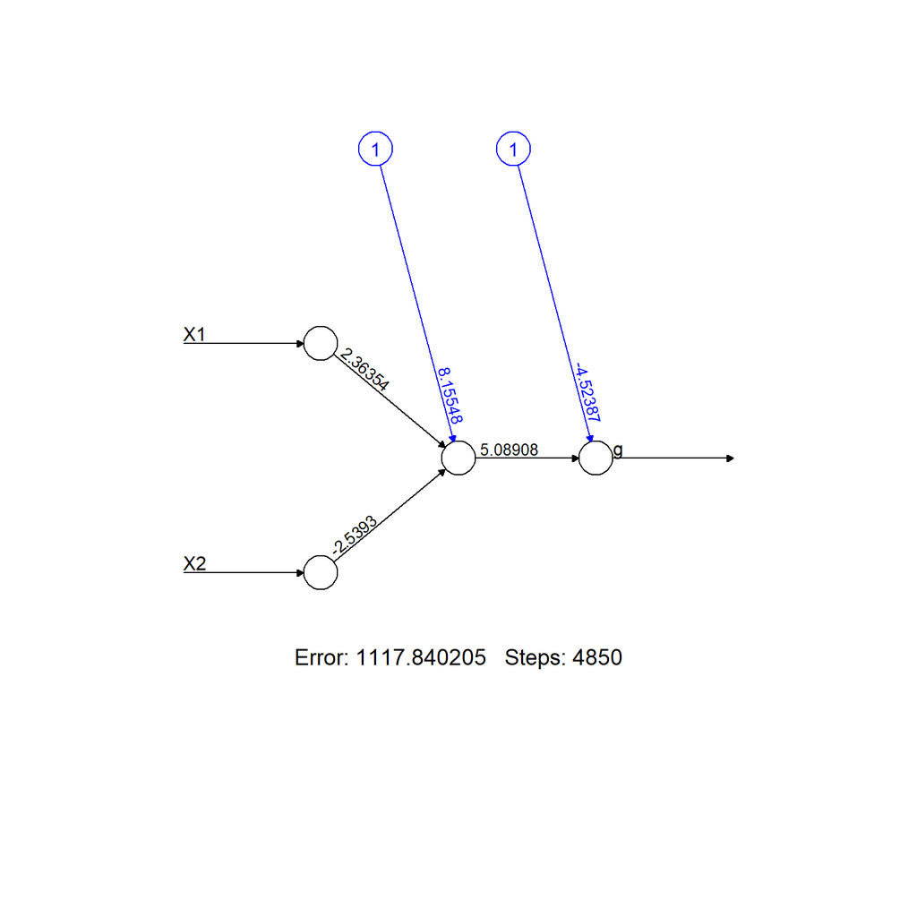

```r
plot(nnResNLO01CE)
```

Once activation function is applied to the output node, the output values are bound to the $[0,1]$ interval. The predicted values that are far enough from the decision boundary are also approximately set to the average of the outcome in that subspace:

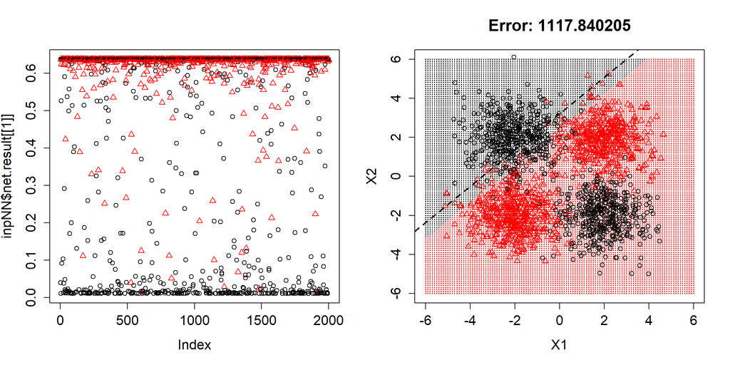

```r
old.par <- par(mfrow=c(1,2),ps=16)
plotNNpreds2D2class(nnResNLO01CE,0.5)
```

```r
par(old.par)
```

The important points resulting from the results shown in the figures above are the following:

- as simple of a model as the one that was employed here (with one node in a single hidden layer along with all other default parameters) cannot do much better than what we observed here
- because calling (default - logistic) activation function on a given linear combination of the input variables more or less amounts to assigning almost all points on one side of hyperplane (line in 2D, plane in 3D, etc.) to zero and on the other side – to unity
- weights involved in transforming outcome of the hidden layer into model predictions will change those zeroes and ones to values closer to the desired outcome values, but still, use of such a simple model (with a single hidden node) employed here to prime our intuition more or less amounts to splitting covariate space into two half spaces by a hyperplane and assigning almost constant outcomes to the vast majority of the points on either side of it
- the weights for the inputs into the single hidden node shown in the network layout plot above and stored in `weights` field of the result returned by `neuralnet` define this hyperplane (line in 2D, etc.) shown as dashes in the panels on the right above
- this hyperplane is where sum of weighted input variables and an intercept is identical zero (and thus the result of logistic activation function is 0.5 rapidly becoming zero or one for points further away from this boundary)

## 1.2 Two hidden nodes, single hidden layer

Now, let’s add another node to the hidden layer of this network. From the above, we know what to expect as a result of that – another hyperplane (line in 2D) will be added to the space of covariates now dividing it into (depending on whether those hyperplans are almost parallel or not) three or four subspaces, consequently, assigning most of the points to three or four potentially different constants. Clearly, this level of granularity could suffice for developing a model that would do quite well in our toy example.

To have more than one node in the hidden layer we set `hidden` parameter to the number of nodes in it (length of vector provided as `hidden` parameter governs the number of the hidden *layers* in the network – we still use one layer here):

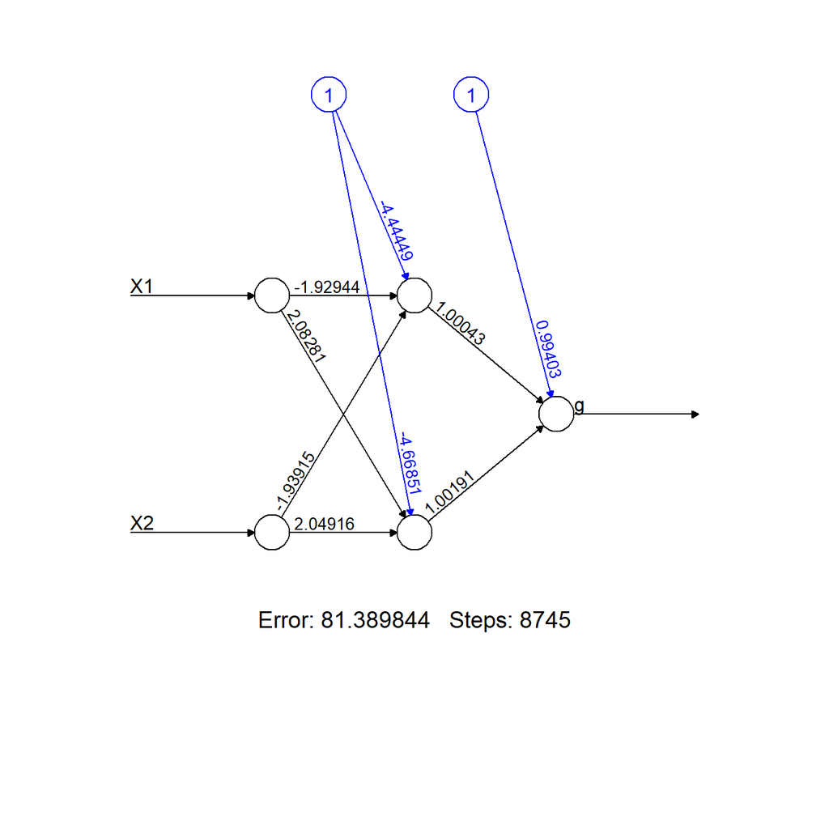

```r
set.seed(1234567)
nnRes2 <- neuralnet(g~X1+X2,data.frame(g=as.numeric(factor(gTmp)),xyTmp),hidden=2)
plot(nnRes2)
```

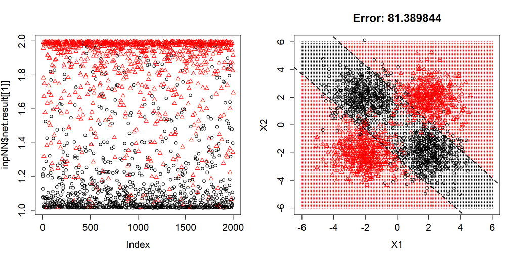

```r
old.par <- par(mfrow=c(1,2),ps=16)
plotNNpreds2D2class(nnRes2,1.5)
```

```r
par(old.par)
```

This model sets up two almost parallel lines that encompass most of the observations from the first class, leaving most of the observations from the second class outside of the resulting slab. Now let’s repeat fitting neural network three times (each time starting with random choice of starting weights in the model) and compare stability of the resulting models:

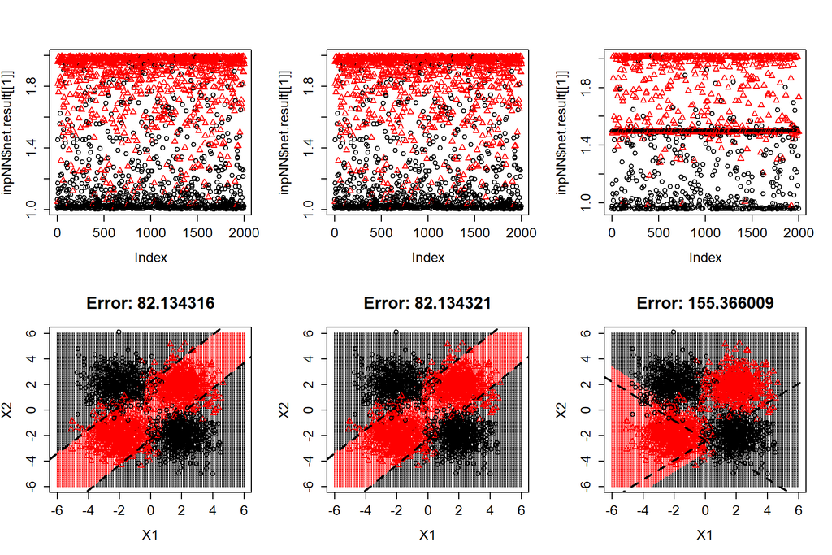

```r
old.par <- par(mfcol=c(2,3),ps=16)
for ( iTry in 1:3 ) {
  nnRes2 <- neuralnet(g~X1+X2,data.frame(g=as.numeric(factor(gTmp)),xyTmp),hidden=2)
  plotNNpreds2D2class(nnRes2,1.5)
}
```

```r
par(old.par)
```

We can see that quite frequently given the parameters used the process converges to a suboptimal solution with about half of the observations remaining in “gray” zone where their assignment to either of the classes is not immediately apparent.

Aside from the multitude of local minima for neural network fitting procedure that could prevent it from finding better solutions, the main point to take from this exercise is that adding more nodes to the hidden layer (with all other default choices employed here) amounts to adding more hyperplanes bisecting the space of predictors, creating more and more subspaces where the outcome can take different values (often close to a constant in each subspace). Obviously, the geometry of the resulting decision surfaces can become quite complicated even with modest number of nodes in the hidden layer. Lastly, these considerations provide some intuition for considering what could be a useful number of hidden nodes in the model. In thinking about that it might be useful to consider how many such hyperplanes could be sufficient to effectively separate observations belonging to different outcome categories. Not that we necessarily would have such knowledge ahead of time, but this might prove to be a complementary way to think about the problem in addition to the often sited empirical guidelines that are based on the number of predictor variables, etc.

The point of this problem set is to assess how these aspects of neural network fitting play out in another simulated dataset.

Lastly, we also would like you to consider what combination of error function and output node transformation you would like to use for this week problem set. Below are three calls of `neuralnet` timed using different combinations of `err.fct` and `linear.output`:

```r
system.time(invisible(neuralnet(g~X1+X2,data.frame(g=as.numeric(factor(gTmp))-1,xyTmp),hidden=2,linear.output = TRUE,err.fct="sse")))
```

```
##    user  system elapsed
##     0.5     0.0     0.5
```

```r
system.time(invisible(neuralnet(g~X1+X2,data.frame(g=as.numeric(factor(gTmp))-1,xyTmp),hidden=2,linear.output = FALSE,err.fct="sse")))
```

```
##    user  system elapsed
##    7.39    0.00    7.39
```

```r
system.time(invisible(neuralnet(g~X1+X2,data.frame(g=as.numeric(factor(gTmp))-1,xyTmp),hidden=2,linear.output = FALSE,err.fct="ce")))
```

```
##    user  system elapsed
##   50.66    0.02   50.72
```

Obviously, for our toy example use of untransformed outcome from the output node and sum of squares as error function results in the fastest convergence. But then the decision as to how to translate its predictions to class categories is yours. On the other hand, one might argue that more principled approach since we are dealing with classification problem would be to use logistic transform of the outcome to contain it within $[0;1]$ interval and cross-entropy as an error function. Except that it seems to run nearly two orders of magnitude slower in this case and does not necessarily converge with default values for the rest of the arguments. Please feel free to experiment with how they will perform for the problems you are presented with below and decide for yourself which combination of these parameters is more suitable for the task at hand.

# 2 Problem 1 (10 points): generate 3D data with cube as a decision surface

Simulate data with n=1000 observations and p=3 covariates – all random values from standard normal distribution ($\mathcal{N}\left(0,1\right), \mu=0,\sigma=1$). Create two category class variable assigning all observations within a cube centered at $(0,0,0)$ with the edge length of $2.5$ (i.e. with vertices at $(1.25,1.25,1.25)$, $(1.25,1.25,-1.25)$, …, $(-1.25,-1.25,-1.25)$) – to one class category and observations outside of this cube – to the second class category. Confirm that the simulated observations are nearly evenly split between the two classes.

Please note that this dataset is entirely different from the one used in the preface – you will need to write code simulating it on your own. Somewhat related 2D dataset was used as a motivational example at week 12 (SVM) lecture before introducing kernels and SVMs. However, the example in the lecture was in 2D (three-dimensional problem here) and had a circular (in 3D – spherical) boundary (here we work with a cube as a decision surface). Since you will be reusing this code in the following two problems it is probably best to turn this procedure into a function with appropriate parameters.

Ten points available for this problem are composed of accomplishing the following tasks:

1. Correct implementation of the function generating data as prescribed above (3 points)
2. Check and demonstrate numerically that the resulting class assignment splits these observations, subject to sampling variability, evenly between these two groups (3 points)
3. Plot values of the resulting covariates projected at each pair of the axes indicating classes to which observations belong with symbol color and/or shape (you can use function `pairs`, for example) (2 points)
4. Reflect on the geometry of this problem by answering the following question: what is the smallest number of planes in 3D space that would completely enclose points from the “inner” class? Is this number equal to the number of cube faces or is it something smaller? Larger? Please note that “enclose” above does *not* mean “perfectly discriminate between the points assigned to two classes” (2 points)

```r
#create data simulator function
data_generator <- function(nObs){
  # 3 coordinate variables drawn from the standard normal distribution:
  x=rnorm(nObs)
  y=rnorm(nObs)
  z=rnorm(nObs)
  # create outcome vector storage
  cl=numeric(nObs)

  #evaulate the class of each data point to see if it's inside the cube
  for (i in 1:nObs){
    if (x[i]<= 1.25 && x[i]>=-1.25 &&
        y[i]<= 1.25 && y[i]>=-1.25 &&
        z[i]<= 1.25 && z[i]>=-1.25){
      #if it is inside, then its class is 1
      cl[i] <- 1
    }
    #if it is not inside, then its class is 0
    else {cl[i] <- 0}
  }

  #joining the predictor variables and the outcome into a dataframe
  data <- as.data.frame(cbind(x, y, z, cl))
  # returning said dataframe from the function
  return(data)
}
```

```r
#generate the dataset with 1000 observations
data <- data_generator(1000)
```

```r
# percent of data points inside the cube
sum(data$cl[data$cl == 1]) / nrow(data) * 100
```

```
## [1] 50.1
```

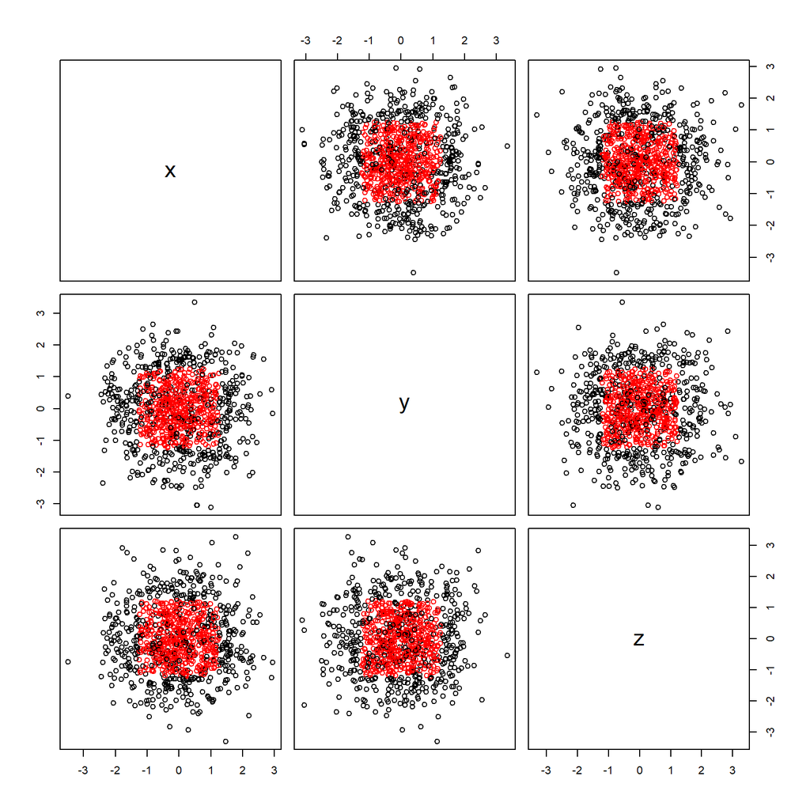

```r
#pair plot of data points in each plane
pairs(data[1:3], col = as.factor(data$cl))
```

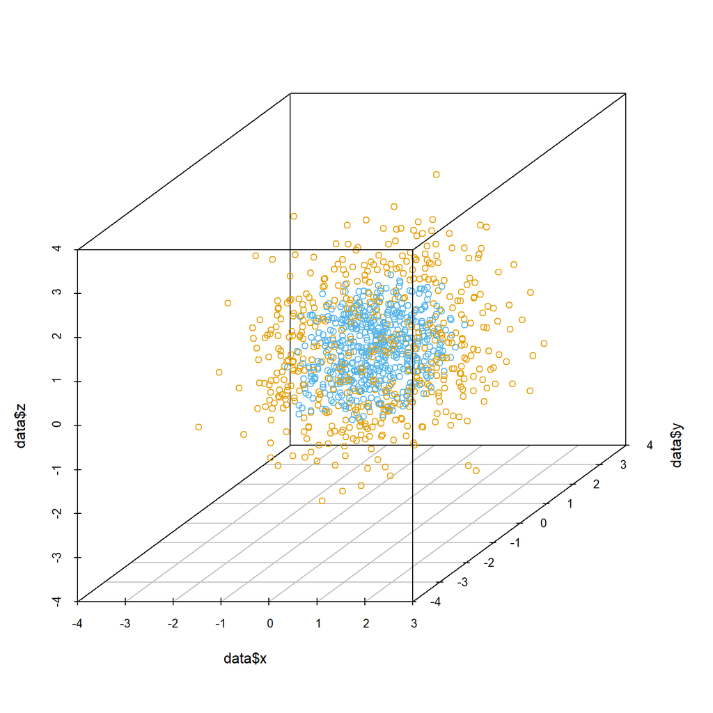

```r
#3D plot of the data
library(scatterplot3d)
colors <- c("#E69F00", "#56B4E9")
colors <- colors[as.factor(data$cl)]
scatterplot3d(x=data$x, y=data$y, z=data$z, color = colors)
```

Using a cross-entropy error calculation method and logistic type output, the cube could be defined with only 3 planes in the 3D space. Each plane would be a side of the cube; one each in the x-y, y-z, x-z space. Each of those planes would also have a DEPENDENT and parallel boundry plane offset from it that represents where the cross entropy error value is somewhere between 0 and 1.